# **Panorama da inflação**

Os principais índices de inflação do Brasil, apontam em abril de 2002 um avanço da inflação de em média **0.68%**. Com esse resultado, no ano a inflação acumula uma variação média positiva de **1.91%**, e em 12 meses uma variação média acumulada de **8.82%**.

|  | Variação mensal | Variação acumulada no ano | Variação acumulada em 12 meses |
| --- | --- | --- | --- |
| IPCA | 0.8% | 2.3% | 7.98% |
| INPC | 0.68% | 2.71% | 9.55% |
| IGP-M | 0.56% | 0.71% | 8.92% |
| IGP-DI | 0.7% | 1% | 8.68% |
| IPA | 0.75% | 0.01% | 0.09% |
| IPC | 0.71% | 1.28% | 7.52% |
| INCC | 0.33% | 1.46% | 9.13% |

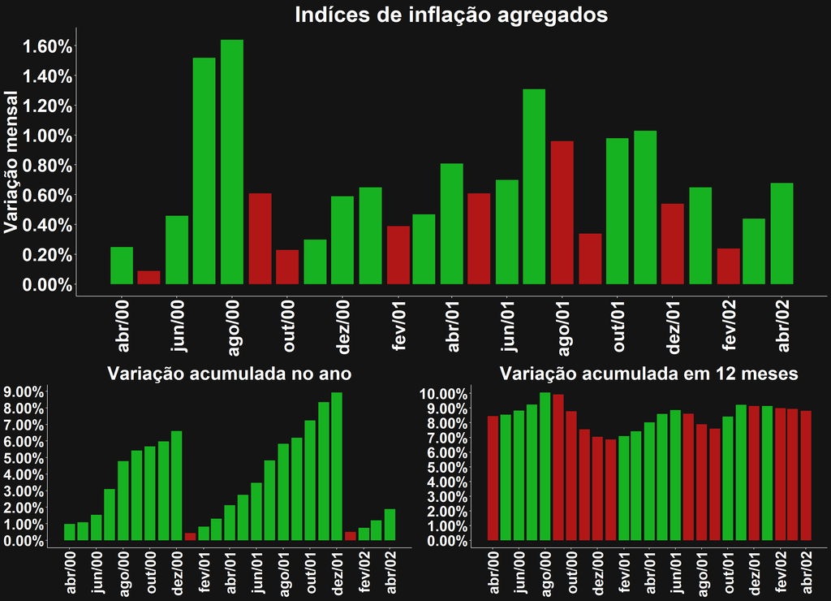

Índices selecionados para a média: IPCA, INPC e IGP-M.

# IPCA

O Indíce de Preços ao Consumidor Amplo (IPCA) variou 0.8% em abril, valor superior ao mesmo período do ano anterior quando apresentou uma taxa de 0.58%. Com esse resultado o indíce acumula no ano uma variação positiva de 2.3%, e em 12 meses uma variação positiva de 7.98%.

|  | 04/2001 | 03/2002 | 04/2002 |
| --- | --- | --- | --- |
| Variação mensal | 0.58% | 0.6% | 0.8% |
| Variação acumulada no ano | 2% | 1.49% | 2.3% |
| Variação acumulada em 12 meses | 6.61% | 7.75% | 7.98% |

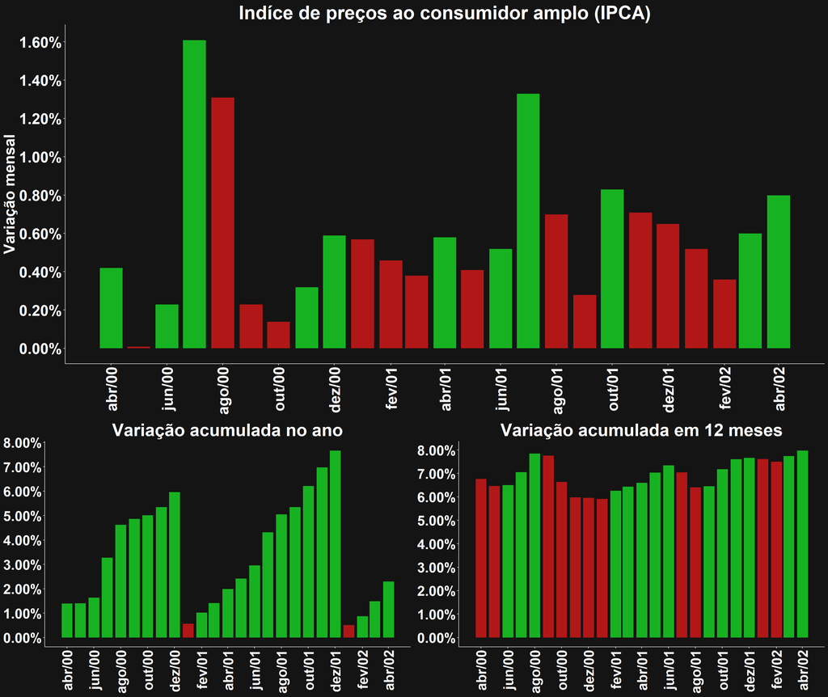

Os grupos que tiveram maior resultado positivo foram Transportes (2.02%) e Habitação (1.4%), e negativo Alimentação e bebidas (-0.32%) e Artigos de residência (-0.02%).

|  | Variação mensal | Variação acumulada no ano | Peso mensal |
| --- | --- | --- | --- |
| Alimentação e bebidas | -0.32% | 1.12% | 22.39% |
| Habitação | 1.4% | 5.46% | 16.44% |
| Artigos de residência | -0.02% | 1.56% | 5.71% |
| Vestuário | 1.05% | 0.93% | 5.29% |
| Transportes | 2.02% | 1.03% | 21.54% |
| Saúde e cuidados pessoais | 0.76% | 3.49% | 10.76% |
| Despesas pessoais | 0.54% | 1.23% | 9.42% |
| Educação | 0.38% | 6.21% | 4.98% |
| Comunicação | 0.01% | 0.86% | 3.47% |

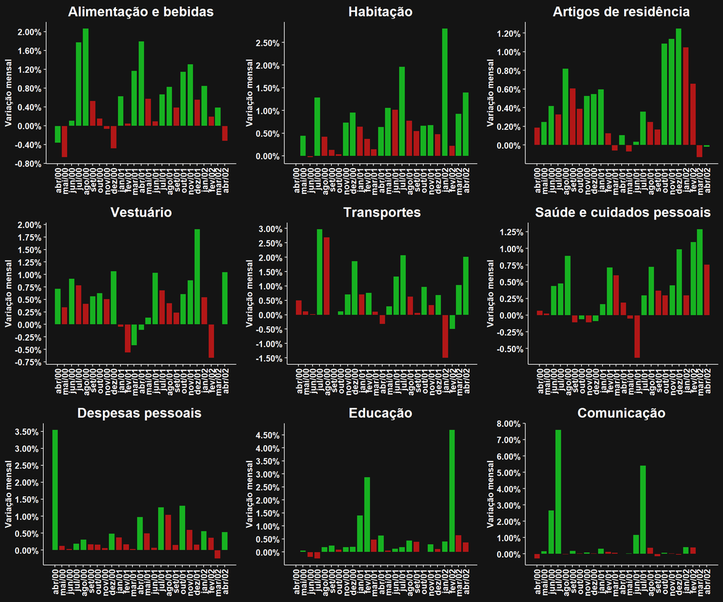

A nível de sub-itens os que mais influenciaram positivamente no resultado em relação ao seu peso foram Gasolina (8.7%%) e Gás de botijão (8.74%%), e negativamente Arroz (-4.64%%) e Frango (-3.76%%).

|  | Variação mensal | Variação acumulada no ano | Peso mensal |
| --- | --- | --- | --- |
| Gás de botijão | 8.74% | 26.09% | 1.53% |
| Gasolina | 8.7% | -3.23% | 3.85% |
| Empregado doméstico | 1.37% | 0.81% | 3.17% |
| Energia elétrica residencial | 1.31% | 8.48% | 4.08% |

|  | Variação mensal | Variação acumulada no ano | Peso mensal |
| --- | --- | --- | --- |
| Alcatra | -1.58% | -2.43% | 0.55% |
| Frango | -3.76% | -2.01% | 0.87% |
| Feijão - preto | -4.05% | -19.68% | 0.18% |
| Arroz | -4.64% | -10.7% | 0.73% |

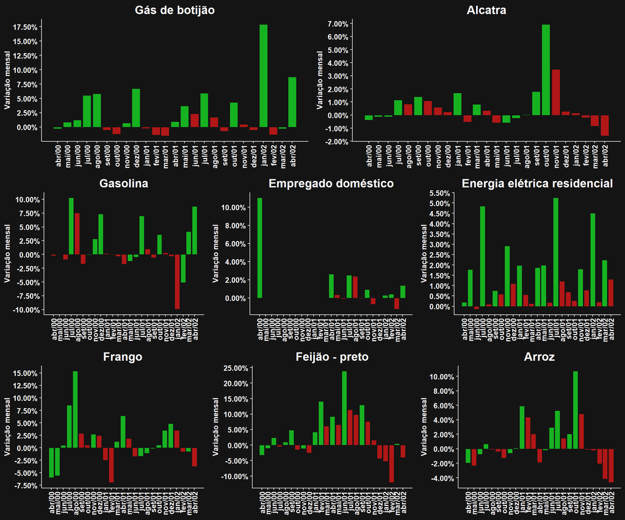